# Rmarkdown template for contribution to Computo

the Computo team

2021-02-11

# Introduction

## About this document

This document provides a Rmarkdown[^1] template for contributions to the **Computo** Journal. We show how `R` or `Python` code can be included.

It also serves as a documentation for configuring the github repository which will host the Rmarkdown source of your manuscript and prove us the reproducibility of your work. To this end, we use binder to generate the final rendering of your manuscript both in HTML and PDF.

## Computo template

In order to submit a manuscript to Computo, you need two thing: first, some scientific content, typically equations, codes and figures, written as a notebook; a second, a proof that this content is reproducible. We choose to do that by means of the standard notebook systems available for R, Python and Julia (Jupyter notebook anbd Rmarkdown) couple to the binder building system.

A Computo template is thus a git(hub) repository typically containing

- the source of the notebook (either Rmarkdown or Jupyter notebook + Myst), here a ‘.Rmd’ file
- some auxiliary files (a BibTeX file .bib, some non-dynamically-generated figures in the repository figs/, etc.)
- some configuration files for the binder environment to setup the machine that will build the final notebook file (HTML and/or PDF)

A thus need to learn

1. How to format a notebook with Rmarkdown or MyST
2. Possibly configure the binder environment (telling which R packages / Python model / system librairies and needed on the virtual machine)

This document will hopefully helps you for both. At the end of the day, a PDF file will be generated directly in the github repository via a github action, ready to be submitted to the Computo submission platform.

## Advice in writting your manuscript

First make sure that you are able to build your manuscript as a regular notebook on your system. Then you can star confugre the binder environment (which we configure to use an Ubuntu machine with last LTS release).

# Formating the notebook

This first part is about writting a notebook with the Rmarkdown system, typically for R users.

## Rmarkdown basics

We first quickly cover rhe most basic features of Rmarkdown, that is, formatting text with markdown, math with $\LaTeX$ via MathJax and bibliographical references via $Bib\TeX$.

### Markdown

`Rmarkdown` allows the user to is the markdown formating system, a simple formatting syntax for authoring HTML, PDF documents. For more details on using R Markdown see http://rmarkdown.rstudio.com.

To render the document as html, click the **Knit** button so that a document will be generated that includes both content as well as the output of any embedded R code chunks within the document. Alternatively, the shortcut Ctrl + Maj + K will produces the same result.

### Mathematical formulae

$\LaTeX$ code is natively supported, which makes it possible to use mathematical formulae:

$$f(x_1, \dots, x_n; \mu, \sigma^2) =
\frac{1}{\sigma \sqrt{2\pi}} \exp{\left(- \frac{1}{2\sigma^2}\sum_{i=1}^n(x_i - \mu)^2\right)}$$

## R code

You can naturally embed an `R` code (R Core Team 2020) chunk like this:

```r
knitr::kable(summary(cars))
```

|  | speed | dist |
| --- | --- | --- |
|  | Min. : 4.0 | Min. : 2.00 |
|  | 1st Qu.:12.0 | 1st Qu.: 26.00 |
|  | Median :15.0 | Median : 36.00 |
|  | Mean :15.4 | Mean : 42.98 |
|  | 3rd Qu.:19.0 | 3rd Qu.: 56.00 |
|  | Max. :25.0 | Max. :120.00 |

[figure not shown]

## Python Code

The R package reticulate (Ushey, Allaire, and Tang 2020) includes a Python engine for R Markdown that enables easy interoperability between Python and R chunks. Below we demonstrate a small subset of the available functionalities. We refer to the vignette [R Markdown Python Engine](https://cran.r-project.org/web/packages/reticulate/vignettes/r_markdown.html) for a more detailed description.

### Setup

```r
library("reticulate")
use_virtualenv("computo-template")
```

Firt make sure (here, in `R`) that the required python modules are available

```r
py_module_available("seaborn") || py_install("seaborn")
py_module_available("pandas") || py_install("pandas")
py_module_available("matplotlib") || py_install("matplotlib")
```

### Using python

Example of python code and associated output:

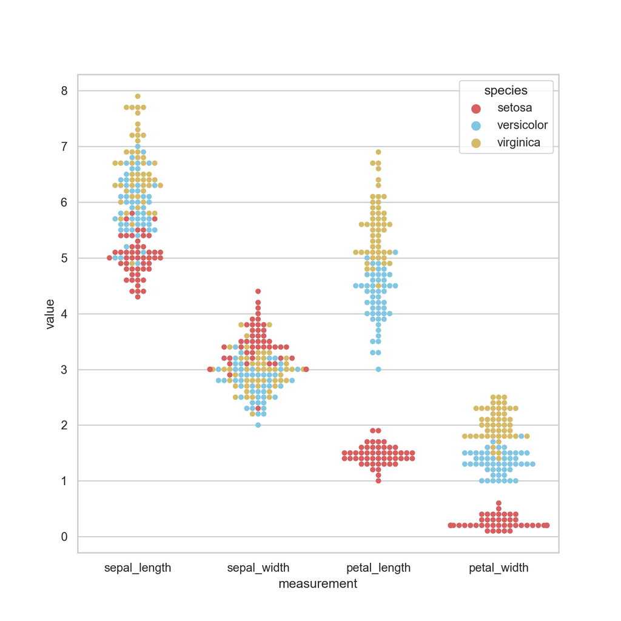

```python
import pandas as pd
import seaborn as sns
import matplotlib.pyplot as plt

sns.set(style="whitegrid", palette="muted")

# Load the example iris dataset
iris = sns.load_dataset("iris")

# "Melt" the dataset to "long-form" or "tidy" representation
iris = pd.melt(iris, "species", var_name="measurement")
plt.figure()

# Draw a categorical scatterplot to show each observation
sns.swarmplot(x="measurement", y="value", hue="species", palette=["r", "c", "y"], data=iris)
plt.show()
```